# UW 350: HW1

### Plot variables that impact Heating/Cooling load

```r
  require(ggplot2)
  # Correlation between Heating/Cooling Load and Roof Area:
  cor(energy$Heating.Load,energy$Roof.Area)
```

```
## [1] -0.8618283
```

```r
  cor(energy$Cooling.Load,energy$Roof.Area)
```

```
## [1] -0.8625466
```

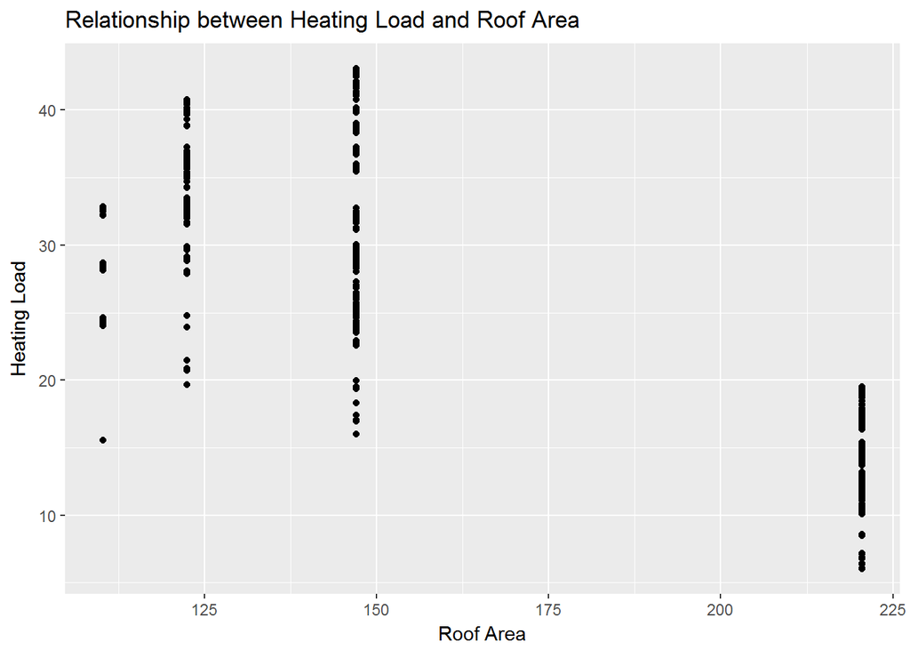

```r
  #Scatter plot of the Heating/Cooling Load and Roof Area
  ggplot(energy, aes(y = Heating.Load, x = Roof.Area))+ geom_point() + xlab("Roof Area") + ylab("Heating Load") + ggtitle("Relationship between Heating Load and Roof Area")
```

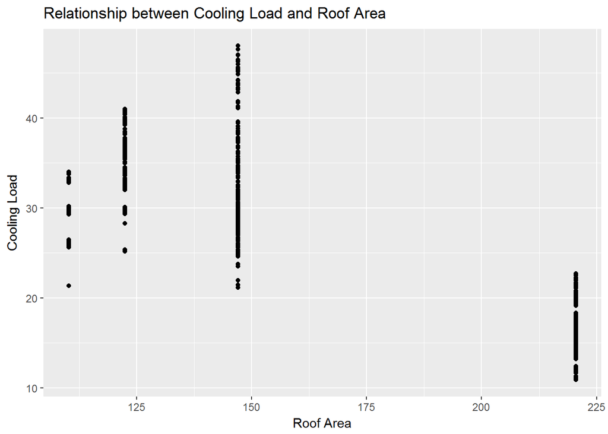

```r
  ggplot(energy, aes(y = Cooling.Load, x = Roof.Area))+ geom_point() + xlab("Roof Area") + ylab("Cooling Load") + ggtitle("Relationship between Cooling Load and Roof Area")
```

- Correlation between Heating Load and Roof Area is : -0.862. Hence there is strong anti-correlation between Roof Area and Heating Load.
- Correlation between Cooling Load and Roof Area is : -0.863. Hence there is strong anti-correlation between Roof Area and Cooling Load.
- The Scatter plot shows that Heating/Cooling load seems to be higher when the Roof Areas is below 150 Units. When the Roof Area is above 200 units the Heating/Cooling load is lower

```r
  # Correlation between Heating/Cooling Load and Overall Height:
  cor(energy$Heating.Load,energy$Overall.Height)
```

```
## [1] 0.8894307
```

```r
  cor(energy$Cooling.Load,energy$Overall.Height)
```

```
## [1] 0.8957852
```

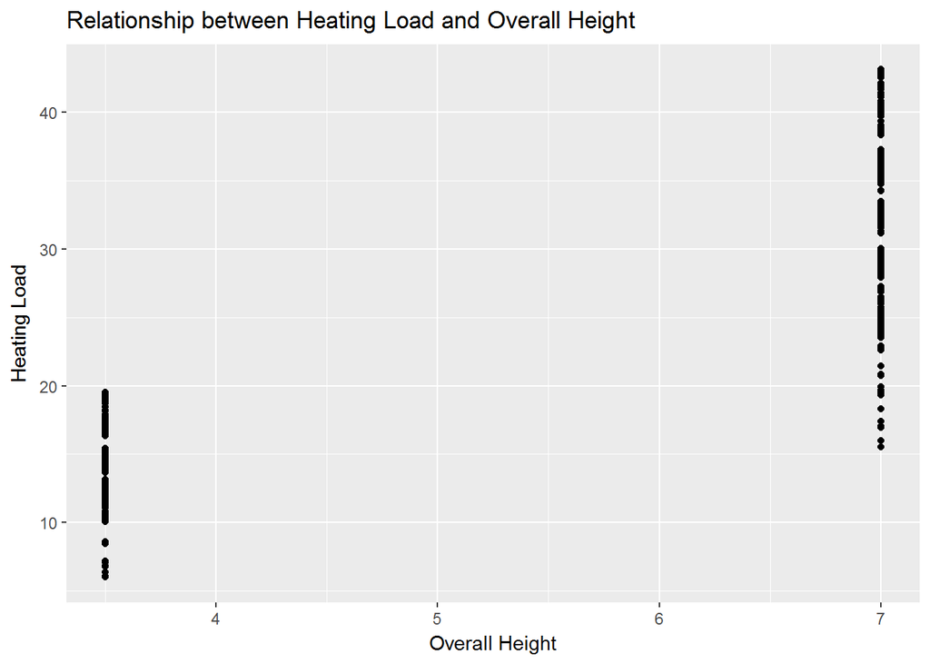

```r
  #Scatter plot of the Heating/Cooling Load and Overall Height
  ggplot(energy, aes(y = Heating.Load, x = Overall.Height))+ geom_point() + xlab("Overall Height") + ylab("Heating Load") + ggtitle("Relationship between Heating Load and Overall Height")
```